# Muestreador de Gibbs

23 de Junio de 2023

## Introducción

Si bien en la vida real es posible encontrarnos con distribuciones de probabilidad sobre las que podemos obtener muestras de forma sencilla se debe decir que este caso es muchísimo menos frecuente que el caso en el que necesitamos lidiar con distribuciones de probabilidad un poco más complejas para las cuales nos es díficil muestrear directamente. Aquí es donde destacan los métodos [MCMC (Markov chain Monte Carlo)](https://en.wikipedia.org/wiki/Markov_chain_Monte_Carlo). Dentro de ellos uno de los métodos más sencillos de implementar y el que, casi siempre, se usa para una primera aproximación a estos métodos es el muestreador de Gibbs.

## Problema

[output not shown]

Se tienen dos monedas: una justa y una trucada con probabilidad \(\scriptsize{3/4}\) de obtener cara y \(\scriptsize{1/4}\) de obtener un sello al lanzarla y se plantea el sistema de juego en los siguientes pasos.

Note que si definimos que \(\scriptsize{0 = Cara}\) y \(\scriptsize{1 = Sello}\) y a las variables aleatorias \(\scriptsize{X = \text{"Primer lanzamiento de una ronda"}}\) e \(\scriptsize{Y = \text{"Segundo lanzamiento en una ronda"}}\) tendremos las siguientes probabilidades condicionales:

- \(\scriptsize{P(Y_n = 0 | X_n = 0) = 1/2}\)
- \(\scriptsize{P(Y_n = 1 | X_n = 0) = 1/2}\)
- \(\scriptsize{P(Y_n = 0 | X_n = 1) = 3/4}\)
- \(\scriptsize{P(Y_n = 1 | X_n = 1) = 1/4}\)
- \(\scriptsize{P(X_n = 0 | Y_n = 0) = 3/4}\)
- \(\scriptsize{P(X_n = 1 | Y_n = 0) = 1/4}\)
- \(\scriptsize{P(X_n = 0 | Y_n = 1) = 1/2}\)
- \(\scriptsize{P(X_n = 1 | Y_n = 1) = 1/2}\)

## Implementación general del algoritmo

El muestreador de Gibbs es un caso específico del algoritmo de Metropolis-Hasting que necesita conocer la distribución condicional de todas las variables aleatorias entre sí pero que con esa información nos puede dar aproximaciones a la distribución tanto conjunta como las marginales de cada variablen este caso específico no parece algo díficil de lograr simplemente a mano. Sin embargo, este algoritmo suele usarse para casos en os que hay más variables implicadas (Estadística Bayesiana).

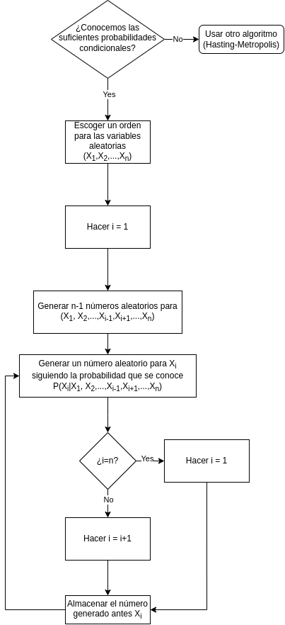

## Algoritmo

```r
muestraG = c()
# Orden del vector de probabilidades dado x = 0: P(Y=0|X=0),P(Y=1,X=0)
x0 = c(0.5,0.5) # Vector de probabilidades para Y dado X=0
x1 = c(0.75,0.25) # Vector de probabilidades para Y dado X=1

y0 = c(0.75,0.25) # Vector de probabilidades para X dado Y=0
y1 = c(0.5,0.5) # Vector de probabilidades para X dado Y=1
x = sample(c(0,1),size=1,prob=c(0.75,0.25))

# Es posible que experimente lentitud al correr el siguiente algoritmo.
for (i in 1:100000){
  if (x == 0){
    proba = x0
  } else {
    proba = x1
  }
  y = sample(c(0,1),size=1,prob=proba)
  muestraG = rbind(muestraG,c(x,y))
  if (y == 0){
    proba = y0
  } else {
    proba = y1
  }
  x = sample(c(0,1),size=1,prob=proba)
}
```

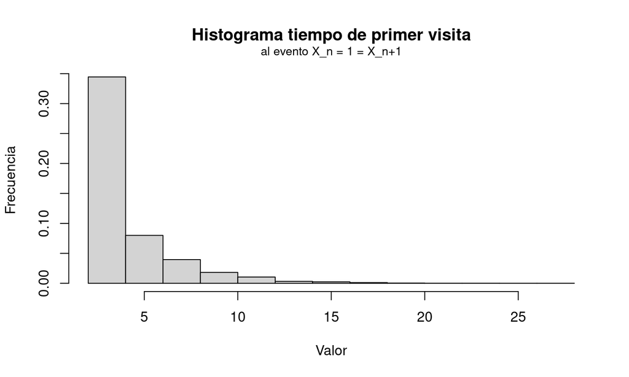

```
## [1] "La media de los tiempos para el caso de la moneda justa fue: 4.1166"
```

[figure not shown]

```
## [1] "La media de los tiempos para el caso de la moneda truncada fue: 3.6584"
```

*Primera llegada al evento \({\scriptsize{(X_n = 0, Y_n = 0)}}\) con 10000 muestras*

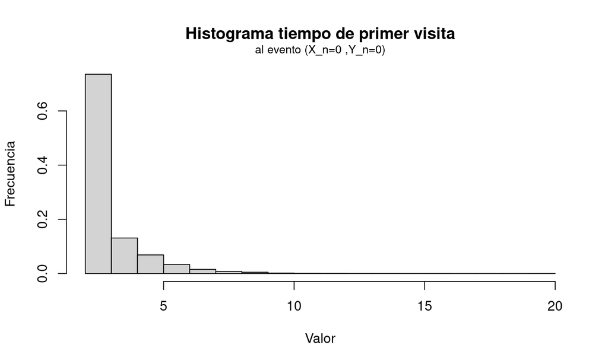

```
## [1] "La media de los tiempos de primer llegada al evento (0,0) fue: 3.051"
```

## ¿Por qué este algoritmo funciona?

[output not shown]

Veáse [Explaining the Gibbs Sampler by George Casella](http://links.jstor.org/sici?sici=0003-1305%28199208%2946%3A3%3C167%3AETGS%3E2.0.CO%3B2-R) para una revisión de la prueba de convergencia para el caso de dos Bernoulli del muestreador de Gibbs (Este caso) y otros detalles respecto al muestreador de Gibbs. En este paper se comprueba que si consignamos las probabilidades de transición en dos matrices separadas de la siguiente forma:

\[ A_{_{Y|X}}= \begin{bmatrix} 1/2&1/2\\ 3/4&1/4\\ \end{bmatrix}\]y\[ A_{_{X|Y}}= \begin{bmatrix} 3/4&1/4\\ 1/2& 1/2\\ \end{bmatrix} \] entonces tendremos que la distribución marginal de \(\scriptsize{X}\) es uno de los vectores solución del sistema \(\scriptsize{\pi A_{_{Y|X}}A_{_{X|Y}} = \pi}\) y del mismo modo para \(\scriptsize{Y}\) es una de las soluciones del sistema \(\scriptsize{\alpha A_{_{X|Y}}A_{_{Y|X}} = \alpha}\)

\[ \alpha \begin{bmatrix} 9/16&7/16\\ 5/8&3/8\\ \end{bmatrix} = \alpha \]

## Las distribuciones marginales y conjuntas.

Uno de los principales usos de la distribución de Gibbs es muestrear distribuciones conjuntas para las cuales es díficil hallarla usando métodos analíticos o otro tipo de métodos de simulación. Con una muestra de 100000 de la secuencia del muestreador de Gibbs obtenemos uns distribucionales marginales para X:

[output not shown]

Y para Y:

[output not shown]

En cuanto a la distribución conjunta se obtiene lo siguiente:

| Cara-Cara | 0.32395 |
| --- | --- |
| Cara-Sello | 0.32383 |
| Sello-Cara | 0.26461 |
| Sello-Sello | 0.08761 |

## Bibliografía

- Casella, G., & George, E. I. (1992). Explaining the Gibbs sampler. The American statistician, 46(3), 167. https://doi.org/10.2307/2685208
- Chapter 6: Gibbs sampling. (s/f). Github.io. Recuperado el 23 de junio de 2023, de https://jwmi.github.io/BMS/chapter6-gibbs-sampling.pdf
- Gibbs sampling example using a discrete distribution. (2018, octubre 26). James D. McCaffrey. https://jamesmccaffrey.wordpress.com/2018/10/26/gibbs-sampling-example-using-a-discrete-distribution/
- Kass, R. E., Carlin, B. P., Gelman, A., & Neal, R. M. (1998). Markov chain Monte Carlo in practice: A roundtable discussion. The American Statistician, 52(2), 93–100. https://doi.org/10.1080/00031305.1998.10480547
- Reversible Markov Chains. (s/f). Berkeley.edu. Recuperado el 23 de junio de 2023, de https://inst.eecs.berkeley.edu/~ee126/sp18/reversibility.pdf